# Part 1 - Preprocessing

SrenBlikdal

2024-04-22

## Preprocessing of WGBS data

Here we present the steps for converting raw 150PE WGBS reads to input for a BSseq methylation analysis in R. The pipeline includes adapter removal, hard trimming of sequencing artifacts, mapping, deduplication, and methylation extraction.

### QC, trimming and QC

Firstly, we have a look the quality of the raw reads using fastqc

```bash
#fastqc - before trimming
cd $raw_data/$SAMPLE
fastqc "$SAMPLE"_1.fq.gz "$SAMPLE"_2.fq.gz -t 10 -o $out_direc/2_fastqc_before/$SAMPLE
```

Most concerning was the base distribution along the position in the read where all reads had a high proportion of Gs in the first 10 bases.

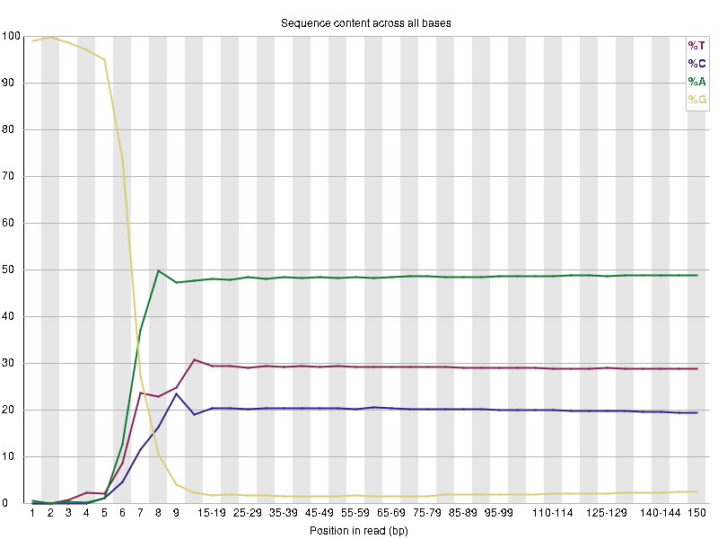

```r
knitr::include_graphics("~/Documents/Silversides_screenshots/Per_base_sequence_content_before.png")
```

To make sure this technical artifact was remomed along with the trimming of adapters we specified clip_R2 -10 in trim_galore

```bash
cd $out_direc/3_trimgalore/$SAMPLE
trim_galore -j 10  --path_to_cutadapt /projects/mjolnir1/apps/conda/cutadapt-3.7/bin/cutadapt --clip_R2 10 --three_prime_clip_R2 2 \
--three_prime_clip_R1 2 --paired $raw_data/$SAMPLE/"$SAMPLE"_1.fq.gz $raw_data/$SAMPLE/"$SAMPLE"_2.fq.gz
```

We check the quality of the reads after trimming and the issue with base distribution along the position in the read

```bash
# fastqc - after trimming
cd $out_direc/3_trimgalore/$SAMPLE
fastqc "$SAMPLE"_1.fq.gz "$SAMPLE"_2.fq.gz -t 10 -o $out_direc/4_fastqc_before/$SAMPLE
```

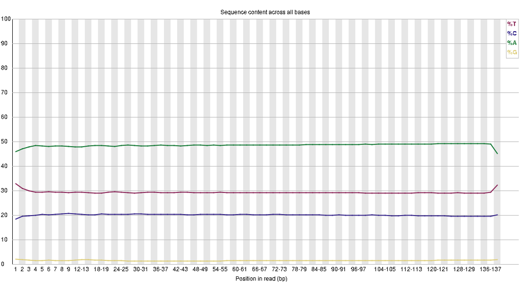

```r
knitr::include_graphics("~/Documents/Silversides_screenshots/Per_base_sequence_content_after.png")
```

It looks a lot better and reads are ready to be mapped against the reference genome.

## Mapping

Group specific reference genomes

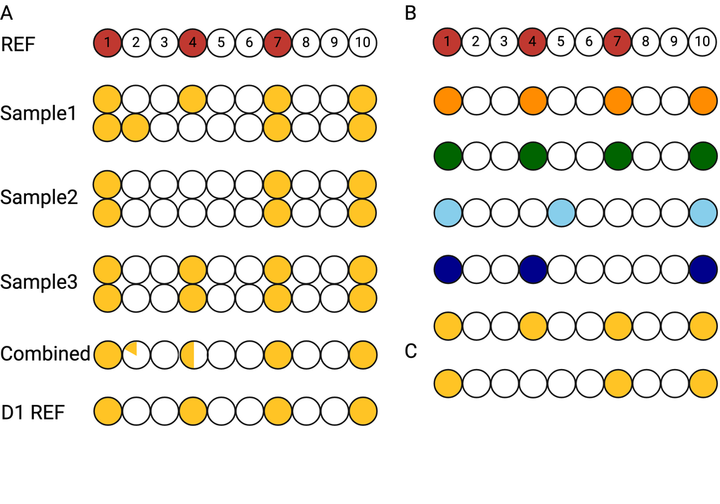

```r
knitr::include_graphics("~/Downloads/Sample snps.png")
```

### Bismark mapping

Map reads from each sample to the group specific reference genome ($ref_genome) using bismark

```bash
#bismark
#To increase the mapping rate
#https://github.com/FelixKrueger/Bismark/blob/master/Docs/FAQ.md#issue-2-low-mapping-effiency-of-paired-end-bisulfite-seq-sample
cd $out_direc/3_trimgalore/$SAMPLE
bismark --parallel 6 --genome $ref_genome --output_dir $out_direc/5_bismark/$SAMPLE --score_min L,0,-0.6 -1 *_1.fq.gz -2 *_2.fq.gz
```

The mapped reads with exactly the same start and end position are likely PCR duplicates, and are removed from the bam file

```bash
# deduplication
cd $out_direc/5_bismark/$SAMPLE
deduplicate_bismark --paired --bam *bam
```

All the information about the methylation we need is stored in the deduplicated bam file, but for convenience we extract it to a format that is easier to work with in R. We use cytosine report format which has strand information which makes it possible to collapse the data from each strand of a CpG site which is assumed to be symmetrical.

```bash
# methylation extraction (excluded "--counts"; excluded "--multi")
cd $out_direc/5_bismark/$SAMPLE
bismark_methylation_extractor -p --gzip --scaffolds --buffer_size 85% --parallel 6 --ignore 0 --ignore_3prime 0  --ignore_3prime_r2 0 --cytosine_report -o $out_direc/5_bismark/$SAMPLE --genome_folder $ref_genome  *deduplicated.bam
```

We use MultiQC to combine the reports from all samples

```bash
multiqc $out_direc/
```

One specific thing to be aware of is the that mean methylation level should be independent of the position in the read, ie. there is no m-bias.

[figure not shown]

```r
knitr::include_graphics("~/Documents/Silversides_screenshots/bismark_mbias_R1.png")
```

[figure not shown]

```r
knitr::include_graphics("~/Documents/Silversides_screenshots/bismark_mbias_R2.png")
```